# Live_Session_Assignment_9

Stuart Miller

June 30, 2019

# Setup

```r
# load libraries
library(tidyverse)
```

# Part A

## 1

```r
# load data
beers <- read.csv('./Beers.csv')
breweries <- read.csv('./Breweries.csv')
# convert column name to match
names(breweries)[1] <- names(beers)[5]
```

## 2

```r
# merge the data
merged_data <- merge(beers,breweries, by = 'Brewery_id')
```

## 3

```r
# convert column to char for easy
merged_data$State <- as.character(merged_data$State)
# remove whitespace
merged_data$State <- gsub('\\s+', '', merged_data$State)
```

## 4

```r
# select data in TX and CO, drop NAs
beerCOTX <- merged_data %>%
  na.omit() %>%
  filter(State == 'TX' | State == 'CO')
```

## 5

```r
beerCOTX <- beerCOTX %>% arrange(IBU)
```

# Part B

## 6

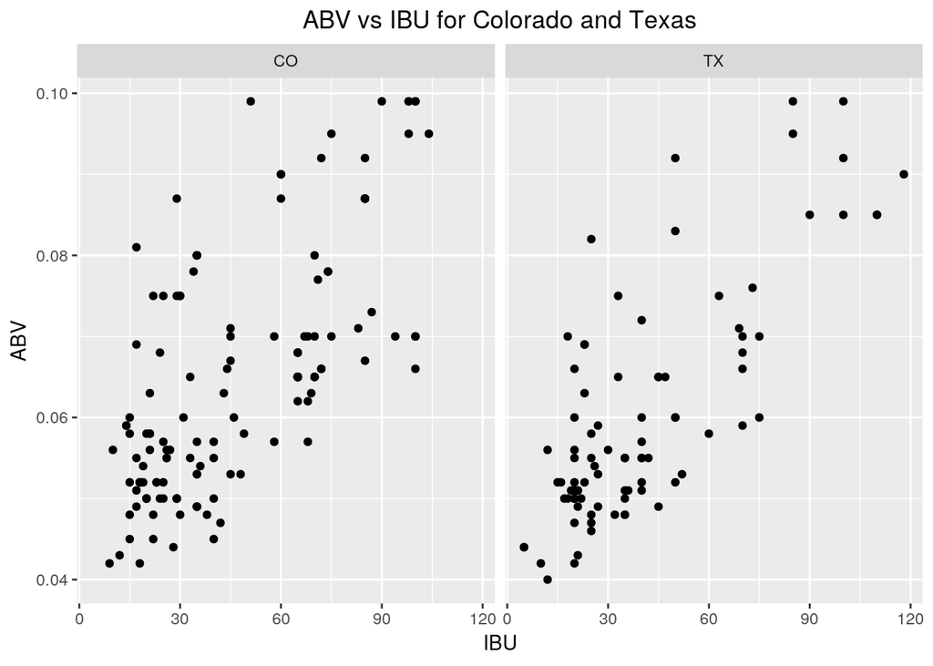

```r
# plot ABV vs IBU for CO and TX
ggplot(beerCOTX, aes(x = IBU, y = ABV)) +
  geom_point() +
  facet_wrap( ~State) +
  labs(title = 'ABV vs IBU for Colorado and Texas') +
  theme(plot.title = element_text(hjust = 0.5))
```

# Part C

## 7 and 8

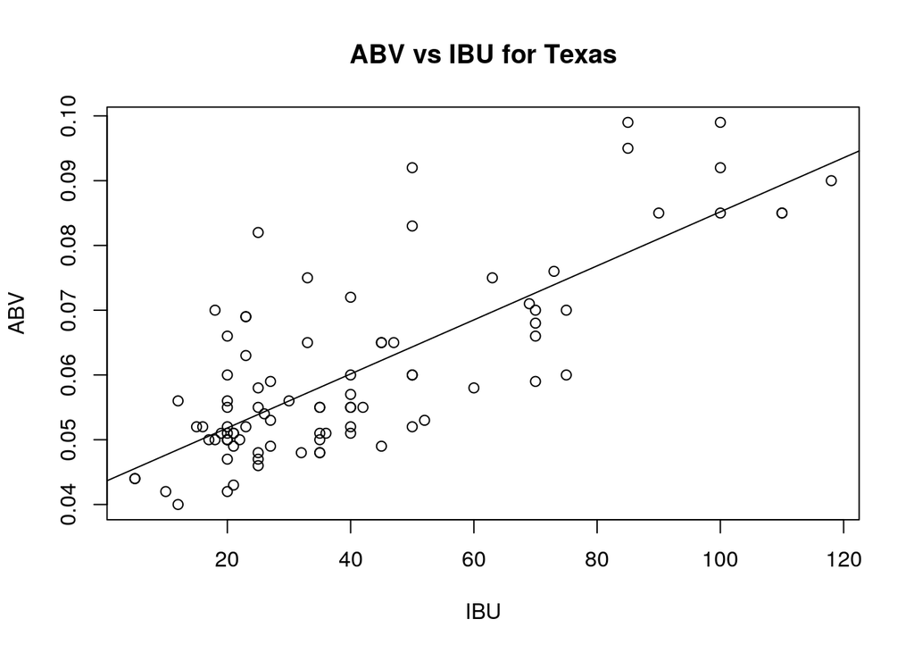

```r
bTX <- beerCOTX %>% filter(State == 'TX')
lmTX <- lm(ABV ~ IBU, bTX)
with(bTX, plot(IBU, ABV, main = 'ABV vs IBU for Texas'))
abline(lmTX)
```

### Addressing Assumptions for Linear Regression

- There does not appear to be significant evidence of normal distributions of ABV for fixed values of IBU for these beers.
- There does not appear to be much evidence against a linear relationship between ABV and IBU for these beers.
- There does not appear to be much evidence against constant variance of the normal distributions.
- We will assume that the observations are independant.

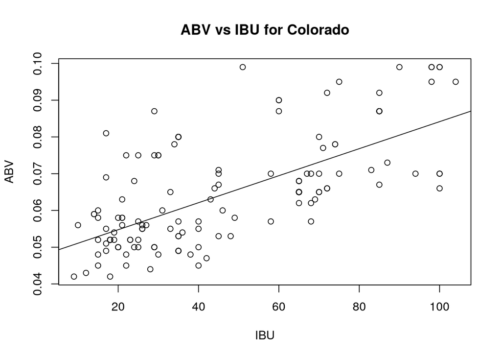

```r
bCO <- beerCOTX %>% filter(State == 'CO')
lmCO <- lm(ABV ~ IBU, bCO)
with(bCO, plot(IBU, ABV, main = 'ABV vs IBU for Colorado'))
abline(lmCO)
```

### Addressing Assumptions for Linear Regression

- There does not appear to be significant evidence of normal distributions of ABV for fixed values of IBU for these beers.
- There does not appear to be much evidence against a linear relationship between ABV and IBU for these beers.
- There does not appear to be much evidence against constant variance of the normal distributions.
- We will assume that the observations are independant.

# Part D

## 9

```r
# print the summary table
summary(lmTX)
```

```
##
## Call:
## lm(formula = ABV ~ IBU, data = bTX)
##
## Residuals:
##       Min        1Q    Median        3Q       Max
## -0.014764 -0.005738 -0.001560  0.003182  0.028096
##
## Coefficients:
##              Estimate Std. Error t value Pr(>|t|)
## (Intercept) 4.347e-02  1.772e-03   24.54   <2e-16 ***
## IBU         4.172e-04  3.683e-05   11.33   <2e-16 ***
## ---
## Signif. codes:  0 '***' 0.001 '**' 0.01 '*' 0.05 '.' 0.1 ' ' 1
##
## Residual standard error: 0.009078 on 87 degrees of freedom
## Multiple R-squared:  0.596,  Adjusted R-squared:  0.5914
## F-statistic: 128.3 on 1 and 87 DF,  p-value: < 2.2e-16
```

There is overwhelming evidence to suggest that the slope of ABV vs IBU is different than zero (p-value < 0.0001). For every unit increase in IBU, there is an associated increase in the mean ABV by 4.172e-04.

```r
# print the summary table
summary(lmCO)
```

```
##
## Call:
## lm(formula = ABV ~ IBU, data = bCO)
##
## Residuals:
##       Min        1Q    Median        3Q       Max
## -0.018158 -0.007266 -0.003293  0.006453  0.032853
##
## Coefficients:
##              Estimate Std. Error t value Pr(>|t|)
## (Intercept) 4.740e-02  1.856e-03   25.54   <2e-16 ***
## IBU         3.676e-04  3.432e-05   10.71   <2e-16 ***
## ---
## Signif. codes:  0 '***' 0.001 '**' 0.01 '*' 0.05 '.' 0.1 ' ' 1
##
## Residual standard error: 0.01077 on 144 degrees of freedom
## Multiple R-squared:  0.4433, Adjusted R-squared:  0.4395
## F-statistic: 114.7 on 1 and 144 DF,  p-value: < 2.2e-16
```

There is overwhelming evidence to suggest that the slope of ABV vs IBU is different than zero (p-value < 0.0001). For every unit increase in IBU, there is an associated increase in the mean ABV by 3.676e-04.

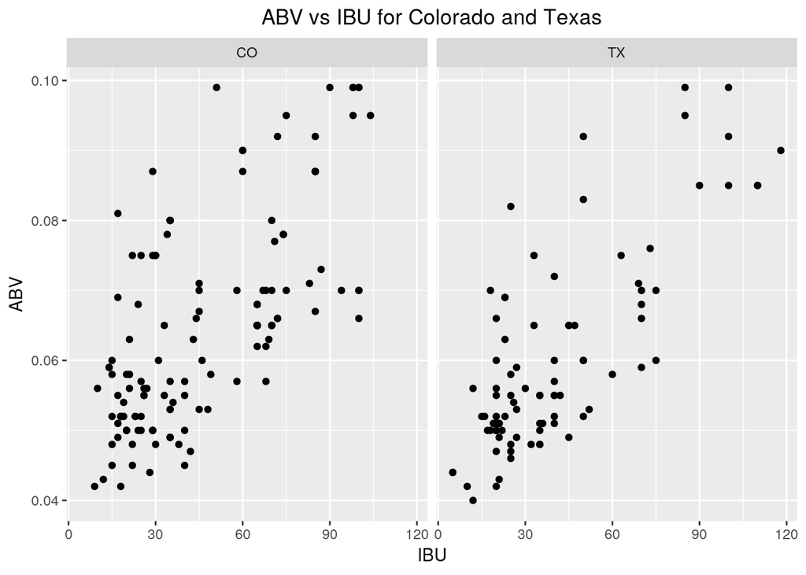

```r
# plot ABV vs IBU for CO and TX
ggplot(beerCOTX, aes(x = IBU, y = ABV)) +
  geom_point() +
  facet_wrap( ~State) +
  labs(title = 'ABV vs IBU for Colorado and Texas') +
  theme(plot.title = element_text(hjust = 0.5))
```

Based on visual inspection of both scatter plots, there does not seem to be a significant difference between the two relationships.

## 10

```r
# print the summary table
confint(lmTX)
```

```
##                   2.5 %       97.5 %
## (Intercept) 0.039952379 0.0469949413
## IBU         0.000344007 0.0004903987
```

We are 95% confident that the associated increase of ABV with unit increase in IBU is between 0.00034 and 0.00049 for Texas beers from this dataset.

```r
# print the summary table
confint(lmCO)
```

```
##                   2.5 %       97.5 %
## (Intercept) 0.043732505 0.0510700022
## IBU         0.000299726 0.0004354124
```

We are 95% confident that the associated increase of ABV with unit increase in IBU is between 0.00030 and 0.00043 for Colorado beers from this dataset.

# Part E

## 11

```r
# create square of IBU column
beerCOTX <- beerCOTX %>% mutate(IBU2 = IBU^2)
head(beerCOTX)
```

```
##   Brewery_id                Name.x Beer_ID   ABV IBU
## 1         67    Yo Soy Un Berliner    2520 0.044   5
## 2        129 18th Anniversary Gose    2370 0.044   5
## 3        392           Agave Wheat    1522 0.042   9
## 4         38          White Rascal     108 0.056  10
## 5         67               Rye Wit    2522 0.042  10
## 6        188             Lobo Lito    2238 0.040  12
##                     Style Ounces                     Name.y           City
## 1      Berliner Weissbier     12   Freetail Brewing Company    San Antonio
## 2                    Gose     12   Real Ale Brewing Company         Blanco
## 3 American Pale Wheat Ale     12       Breckenridge Brewery         Denver
## 4                 Witbier     12      Avery Brewing Company        Boulder
## 5                 Witbier     12   Freetail Brewing Company    San Antonio
## 6             Light Lager     12 Pedernales Brewing Company Fredericksburg
##   State IBU2
## 1    TX   25
## 2    TX   25
## 3    CO   81
## 4    CO  100
## 5    TX  100
## 6    TX  144
```

## 12

Spilt data into training and testing sets for model validation

```r
beerTX <- beerCOTX %>%
  na.omit() %>%
  filter(State == 'TX')

## 60% of the sample size
smp_size <- floor(0.60 * nrow(beerTX))

# seed random
set.seed(123)

train_ind <- sample(seq_len(nrow(beerTX)), size = smp_size)

# get training and testing data
trainingTX <- beerTX[train_ind, ]
testingTX <- beerTX[-train_ind, ]

beerCO <- beerCOTX %>%
  na.omit() %>%
  filter(State == 'CO')

## 60% of the sample size
smp_size <- floor(0.60 * nrow(beerCO))

# seed random
set.seed(123)

train_ind <- sample(seq_len(nrow(beerCO)), size = smp_size)

# get training and testing data
trainingCO <- beerCO[train_ind, ]
testingCO <- beerCO[-train_ind, ]
```

## 13

Define some helper functions for the external cross validation analysis.

```r
# define a function for ASE calculation
ASE <- function(y, y_hat) {
  result <- sum((y-y_hat)^2)/length(y)
  return(result)
}

# get lm coefficients
getLMCoe <- function(model, linearM = TRUE){
  if (linearM) {
    beta1 <- as.numeric(lmCO$coefficients['IBU'])
    beta0 <- as.numeric(lmCO$coefficients['(Intercept)'])
    return(c(beta0, beta1))
  } else {
    beta2 <- as.numeric(lmCO$coefficients['IBU2'])
    beta1 <- as.numeric(lmCO$coefficients['IBU'])
    beta0 <- as.numeric(lmCO$coefficients['(Intercept)'])
    return(c(beta0, beta1, beta2))
  }
}

# predict based on model
pred <-function(X, model, linearM = TRUE){
  if (linearM) {
    y_h <- model[1] + model[2]*X
  } else {
    y_h <- model[1] + model[2]*X + model[2]*(X^2)
  }
  return(y_h)
}

# define a function to calculate model loss from dataframe and model inputs
calcModelLoss <- function(df, model, linearM = TRUE){
  X <- df$IBU
  predABV <- pred(X, getLMCoe(model), linearM)
  ASE(df$ABV, predABV)
}
```

Check if linear model or quadratic model works best for the beers from TX and CO.

```r
# train linear models for both states
lmTX <- lm(ABV ~ IBU, trainingTX)
lmCO <- lm(ABV ~ IBU, trainingCO)

# train linear-quadratic models for both states
lmqTX <- lm(ABV ~ IBU + IBU2, trainingTX)
lmqCO <- lm(ABV ~ IBU + IBU2, trainingCO)

# test linear model on TX data
print('test linear model on TX data')
```

```
## [1] "test linear model on TX data"
```

```r
calcModelLoss(testingTX, lmTX)
```

```
## [1] 8.137036e-05
```

```r
# test quadratic model on TX data
print('test quadratic model on TX data')
```

```
## [1] "test quadratic model on TX data"
```

```r
calcModelLoss(testingTX, lmqTX, F)
```

```
## [1] 0.4504132
```

```r
# test linear model on CO data
print('test linear model on CO data')
```

```
## [1] "test linear model on CO data"
```

```r
calcModelLoss(testingCO, lmCO)
```

```
## [1] 0.0001124125
```

```r
# test quadratic model on TX data
print('test quadratic model on CO data')
```

```
## [1] "test quadratic model on CO data"
```

```r
calcModelLoss(testingCO, lmqCO, F)
```

```
## [1] 1.91187
```

### Analysis of Modeling

Brewmeisters want to determine if a quadratic model or a linear model represents the data best.

**Linear Model**

$$ABV = \beta_0 + \beta_1(IBU)$$

**Quadratic Model**

$$ABV = \beta_0 + \beta_1(IBU)+\beta_2(IBU)^2$$

To determine the best fitting model, the models will be fit to the data with a ‘training’ set and tested with a ‘test’ set. The quality of each model will be determined using average squared error (ASE) as a loss function. A loss function calculates the error between the actual responses and the predicted responses (ABV in this case). Naturally, a model with a lower loss is a better fit to the data. The tables below shows the ASE for models of ‘ABV explained by IBU’ for Texas and Colorado beers.

**Loss Function**

$$ASE = \frac{\sum_{n=1}^{N} (y_i - \hat{y}_i)^2 }{N}$$

#### Texas Model Validation Results

| Model | ASE |
| --- | --- |
| Linear | 8.14e-05 |
| Quadratic | 0.45 |

#### Colorado Model Validation Results

| Model | ASE |
| --- | --- |
| Linear | 1.12e-04 |
| Quadratic | 1.91 |

## 13 - Bonus

Another source of evidence is the statistical significance of the quadratic fit. The `lm` function provides statistical significance directly from the fit.

```r
summary(lmTX)
```

```
##
## Call:
## lm(formula = ABV ~ IBU, data = trainingTX)
##
## Residuals:
##       Min        1Q    Median        3Q       Max
## -0.012650 -0.006467 -0.001953  0.003350  0.029552
##
## Coefficients:
##              Estimate Std. Error t value Pr(>|t|)
## (Intercept) 4.095e-02  2.340e-03   17.50  < 2e-16 ***
## IBU         4.601e-04  4.267e-05   10.78 9.27e-15 ***
## ---
## Signif. codes:  0 '***' 0.001 '**' 0.01 '*' 0.05 '.' 0.1 ' ' 1
##
## Residual standard error: 0.008978 on 51 degrees of freedom
## Multiple R-squared:  0.6951, Adjusted R-squared:  0.6891
## F-statistic: 116.3 on 1 and 51 DF,  p-value: 9.266e-15
```

```r
confint(lmTX)
```

```
##                    2.5 %      97.5 %
## (Intercept) 0.0362478720 0.045645273
## IBU         0.0003744149 0.000545724
```

```r
summary(lmqTX)
```

```
##
## Call:
## lm(formula = ABV ~ IBU + IBU2, data = trainingTX)
##
## Residuals:
##       Min        1Q    Median        3Q       Max
## -0.012286 -0.006548 -0.001871  0.003263  0.029452
##
## Coefficients:
##              Estimate Std. Error t value Pr(>|t|)
## (Intercept) 4.215e-02  4.648e-03   9.067 3.91e-12 ***
## IBU         4.046e-04  1.903e-04   2.126   0.0384 *
## IBU2        4.614e-07  1.541e-06   0.299   0.7658
## ---
## Signif. codes:  0 '***' 0.001 '**' 0.01 '*' 0.05 '.' 0.1 ' ' 1
##
## Residual standard error: 0.00906 on 50 degrees of freedom
## Multiple R-squared:  0.6957, Adjusted R-squared:  0.6835
## F-statistic: 57.15 on 2 and 50 DF,  p-value: 1.213e-13
```

#### Significance of Model Parameters for Texas

When the two models are fit, the statistical results indicate that the leading order parameter for the linear model is statistically significant, but the leading order parameter of the quadratic fit is not statistically significant at the 95% confidence level. This is consistent with the results of the ASE model validation.

##### Linear Model

There is strong evidence that $\hat{\beta_1}$ is different than zero (p-value < 0.0001). The best estimate of $\hat{\beta_1}$ is 4.601e-04 with 95% confidence interval of [3.74e-4,5.46e-4].

##### Quadratic Model

There no apparent evidence that $\hat{\beta_2}$ is different than zero (p-value = 0.7658).

```r
summary(lmCO)
```

```
##
## Call:
## lm(formula = ABV ~ IBU, data = trainingCO)
##
## Residuals:
##       Min        1Q    Median        3Q       Max
## -0.017287 -0.007192 -0.003598  0.005827  0.028428
##
## Coefficients:
##              Estimate Std. Error t value Pr(>|t|)
## (Intercept) 4.878e-02  2.410e-03  20.239  < 2e-16 ***
## IBU         3.378e-04  4.495e-05   7.515 5.31e-11 ***
## ---
## Signif. codes:  0 '***' 0.001 '**' 0.01 '*' 0.05 '.' 0.1 ' ' 1
##
## Residual standard error: 0.01093 on 85 degrees of freedom
## Multiple R-squared:  0.3992, Adjusted R-squared:  0.3921
## F-statistic: 56.47 on 1 and 85 DF,  p-value: 5.311e-11
```

```r
confint(lmCO)
```

```
##                    2.5 %       97.5 %
## (Intercept) 0.0439835036 0.0535666198
## IBU         0.0002484298 0.0004271872
```

```r
summary(lmqCO)
```

```
##
## Call:
## lm(formula = ABV ~ IBU + IBU2, data = trainingCO)
##
## Residuals:
##       Min        1Q    Median        3Q       Max
## -0.017921 -0.006775 -0.003892  0.005120  0.028557
##
## Coefficients:
##              Estimate Std. Error t value Pr(>|t|)
## (Intercept) 5.070e-02  4.634e-03  10.941   <2e-16 ***
## IBU         2.402e-04  2.050e-04   1.172    0.245
## IBU2        9.196e-07  1.884e-06   0.488    0.627
## ---
## Signif. codes:  0 '***' 0.001 '**' 0.01 '*' 0.05 '.' 0.1 ' ' 1
##
## Residual standard error: 0.01098 on 84 degrees of freedom
## Multiple R-squared:  0.4009, Adjusted R-squared:  0.3866
## F-statistic:  28.1 on 2 and 84 DF,  p-value: 4.529e-10
```

#### Significance of Model Parameters for Colorado

When the two models are fit, the statistical results indicate that the leading order parameter for the linear model is statistically significant, but the leading order parameter of the quadratic fit is not statistically significant at the 95% confidence level. This is consistent with the results of the ASE model validation.

##### Linear Model

There is strong evidence that $\hat{\beta_1}$ is different than zero (p-value < 0.0001). The best estimate of $\hat{\beta_1}$ is 3.378e-04 with 95% confidence interval of [2.48e-4,4.27e-4].

##### Quadratic Model

There no apparent evidence that $\hat{\beta_2}$ is different than zero (p-value = 0.627).